# Lab 4: Tidying and Joining

Hannah Lo(halo-ds) and Yuma Anderson(yumaanderson)

10/24/2019

## Part One: Cleaning Data

Changed the player names and opponent names to factors.

```r
defense$Name <- as.factor(defense$Name)
defense$Opponent_Opponent <- as.factor(defense$Opponent_Opponent)

offense$Name <- as.factor(offense$Name)
offense$Opponent_Opponent <- as.factor(offense$Opponent_Opponent)

bio$Name <- as.factor(bio$Name)
```

Changed the offensive and defensive statistics to numerical, along with the ‘Weight’ column of Biography.

```r
bio$Weight <- as.numeric(bio$Weight)

offClean <- offense %>% mutate_if(is.character, as.numeric)
defClean <- defense %>% mutate_if(is.character, as.numeric)
```

Separated the `Height` column into two columns, and made sure the newly created columns are numeric. After, we created one column that represents `Height`. Lastly, we dropped the columns ‘Feet’ and ‘Inches’ from biography.

```r
bio <- separate(data = bio, col = Height, into = c("Feet", "Inches"), sep = "-")
bio$Feet <- as.numeric(bio$Feet)
bio$Inches <- as.numeric(bio$Inches)
bio$HeightinInches <- (bio$Feet * 12 ) + bio$Inches
bioClean <- subset(bio, select = -c(Feet, Inches))
```

We have the following three clean data frames: `defClean`, `offClean`, and `bioClean`. These are their following structures of these data frames:

```r
str(bioClean)
```

```
## Classes 'tbl_df', 'tbl' and 'data.frame':    123 obs. of  7 variables:
##  $ Name          : Factor w/ 123 levels "Akers, Landen",..: 1 2 3 4 5 6 7 8 9 10 ...
##  $ Position      : chr  "Wide Receiver" "Tight End" "Offensive Line" "Tight End" ...
##  $ Weight        : num  192 240 290 250 191 205 192 224 251 284 ...
##  $ Class         : chr  "Redshirt Sophomore" "Redshirt Sophomore" "Redshirt Freshman" "Redshirt Senior" ...
##  $ Hometown      : chr  "Cedar Rapids, Iowa" "Nixa, Mo." "Cedar Rapids, Iowa" "League City, Texas" ...
##  $ Highschool    : chr  "Washington" "Nixa" "Washington" "Clear Falls" ...
##  $ HeightinInches: num  72 79 74 76 72 71 72 75 74 74 ...
```

```r
str(offClean)
```

```
## Classes 'tbl_df', 'tbl' and 'data.frame':    168 obs. of  12 variables:
##  $ Name             : Factor w/ 15 levels "Akers, Landen",..: 6 6 6 6 6 6 6 6 6 6 ...
##  $ Opponent_Opponent: Factor w/ 13 levels "Akron","Baylor",..: 4 7 1 9 8 13 11 5 2 10 ...
##  $ Receiving_REC    : num  1 9 6 3 6 1 1 4 4 0 ...
##  $ Receiving_YDS    : num  31 66 39 23 37 32 4 31 39 0 ...
##  $ Receiving_TD     : num  0 0 0 0 1 1 0 0 1 0 ...
##  $ Rushing_ATT      : num  NA NA NA NA NA NA NA NA NA NA ...
##  $ Rushing_YDS      : num  NA NA NA NA NA NA NA NA NA NA ...
##  $ Rushing_TD       : num  NA NA NA NA NA NA NA NA NA NA ...
##  $ Passing_CMP-ATT  : num  NA NA NA NA NA NA NA NA NA NA ...
##  $ Passing_YDS      : num  NA NA NA NA NA NA NA NA NA NA ...
##  $ Passing_TD       : num  NA NA NA NA NA NA NA NA NA NA ...
##  $ Passing_INT      : num  NA NA NA NA NA NA NA NA NA NA ...
```

```r
str(defClean)
```

```
## Classes 'tbl_df', 'tbl' and 'data.frame':    446 obs. of  11 variables:
##  $ Name             : Factor w/ 42 levels "Akers, Landen",..: 7 7 7 7 7 7 7 7 7 7 ...
##  $ Opponent_Opponent: Factor w/ 13 levels "Akron","Baylor",..: 4 7 1 9 8 13 11 5 2 10 ...
##  $ Tackles_Solo     : num  3 6 7 6 3 5 3 7 2 9 ...
##  $ Tackles_ASST     : num  3 8 2 3 0 3 2 1 4 3 ...
##  $ Tackles_TFL      : num  0 1 1 0 1 1 0 0 0 0 ...
##  $ Tackles_Sack     : num  0 0 0 0 0 1 0 0 0 0 ...
##  $ Turnover_FF      : num  0 1 0 0 0 0 0 0 0 1 ...
##  $ Turnover_FR      : num  0 0 0 0 0 0 0 0 0 0 ...
##  $ Turnover_INT     : num  0 0 0 0 0 0 1 0 0 0 ...
##  $ Pass_QBH         : num  0 0 0 0 0 0 0 0 0 0 ...
##  $ Pass_PB          : num  0 0 3 0 0 0 0 0 0 0 ...
```

## Part Two: Tidying (A)

We reformated the `defClean` data frame into a tidy format using `gather` on the type of statistic (Tackles_Solo, Tackles_ASST, etc) resulting in a new column ‘Statistic.’

```r
defClean = defClean %>% gather(key=Statistics, value=score,3:11)
defClean$Statistics <- as.factor(defClean$Statistics)
# making categories of defense statistics clear
defClean$Statistics = revalue(defClean$Statistics, c("Turnover_FF" ="Turnover_Forced_Fumble", "Turnover_FR"="Turnover_Fumble_Recovered","Turnover_INT"="Turnover_Interception"))
```

The following is a histogram for each defensive statistic. Turnovers by forced fumble, fumble recover, and interception are rare defensive skills.

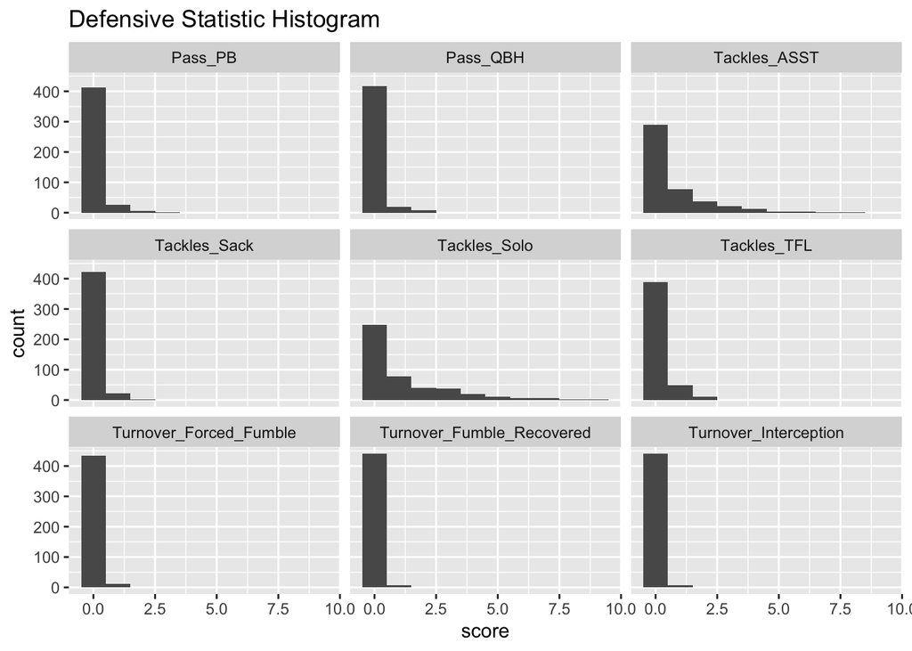

```r
defClean %>% ggplot(aes(score))+geom_histogram(binwidth = 1) +facet_wrap(~Statistics)+labs(title= 'Defensive Statistic Histogram')
```

ISU had a better defense against Kansas State than West Virginia. This is shown by a scatterplot with the x-axis being the number of solo tackles against West Virginia and the y-axis being that against Kansas State.

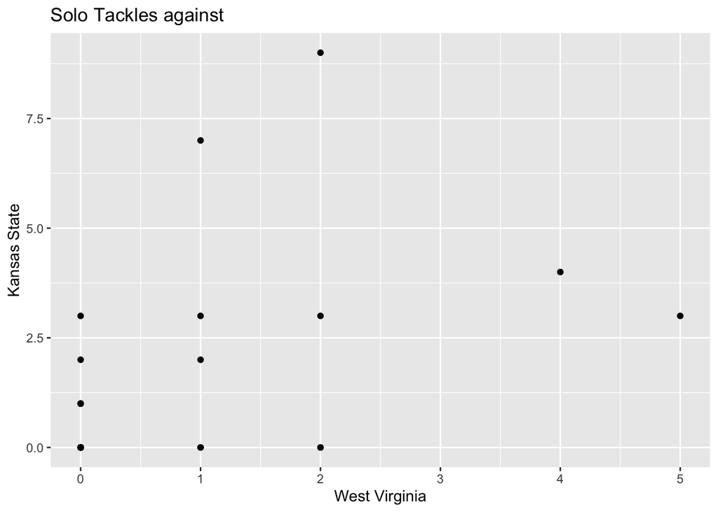

```r
defClean %>% subset(Statistics == "Tackles_Solo") %>% spread(key=Opponent_Opponent, value = score) %>% select(`West Virginia`, `Kansas State`) %>% ggplot(aes(x=`West Virginia`,y=`Kansas State`)) + geom_point() + labs(title='Solo Tackles against')
```

## Part two: Tidying (B)

We separated the Hometown column into two columns by the city and state.

```r
bioClean = separate(data = bioClean, col = Hometown, into = c("City", "State"), sep = ",")
bioClean[1:2,]
```

```
## # A tibble: 2 x 8
##   Name    Position   Weight Class    City   State Highschool HeightinInches
##   <fct>   <chr>       <dbl> <chr>    <chr>  <chr> <chr>               <dbl>
## 1 Akers,… Wide Rece…    192 Redshir… Cedar… " Io… Washington             72
## 2 Allen,… Tight End     240 Redshir… Nixa   " Mo… Nixa                   79
```

The following table shows how many players there are from each state:

```r
table(bioClean$State)
```

```
##
##      Ariz.       Ark.  Australia     Calif.       D.C.       Fla.
##          3          2          2          8          1          8
##        Ga.       Ill.       Iowa       Kan.      Mass.        Md.
##          2          5         44          3          1          1
##      Mich.      Minn.      Miss.        Mo.       Neb.    Nigeria
##          5          2          1          1          1          1
##       Ohio      Okla.        Pa.       S.C.      Texas        Va.
##         10          4          2          2          9          1
##       Wis.
##          4
```

## Part three: Joining data frames

By completing a left join on the offensive data and player biography data, the following table was made showing all offensive player’s hometowns.

```r
off_bio = left_join(offClean, bioClean, by = "Name")
off_bio %>% group_by(Name) %>% select(City,State) %>% distinct()
```

```
## # A tibble: 15 x 3
## # Groups:   Name [15]
##    Name              City         State
##    <chr>             <chr>        <chr>
##  1 Jones, Deshaunte  Cincinnati   " Ohio"
##  2 Milton, Tarique   Bradenton    " Fla."
##  3 Butler, Hakeem    Baltimore    " Md."
##  4 Lang, Johnnie     Palmetto     " Fla."
##  5 Akers, Landen     Cedar Rapids " Iowa"
##  6 Kolar, Charlie    Norman       " Okla."
##  7 Montgomery, David Cincinnati   " Ohio"
##  8 Purdy, Brock      Gilbert      " Ariz."
##  9 Nwangwu, Kene     Frisco       " Texas"
## 10 Noland, Zeb       <NA>         <NA>
## 11 Kempt, Kyle       Massillon    " Ohio"
## 12 Eaton, Matthew    Norfolk      " Va."
## 13 Allen, Chase      Nixa         " Mo."
## 14 Seonbuchner, Sam  Oconomowoc   " Wis."
## 15 Johnson, Josh     Little Rock  " Ark."
```

There is no relationship between the weight of a player and receiving yards. This is shown by the following scatterplot of the receiving yards by a player’s weight:

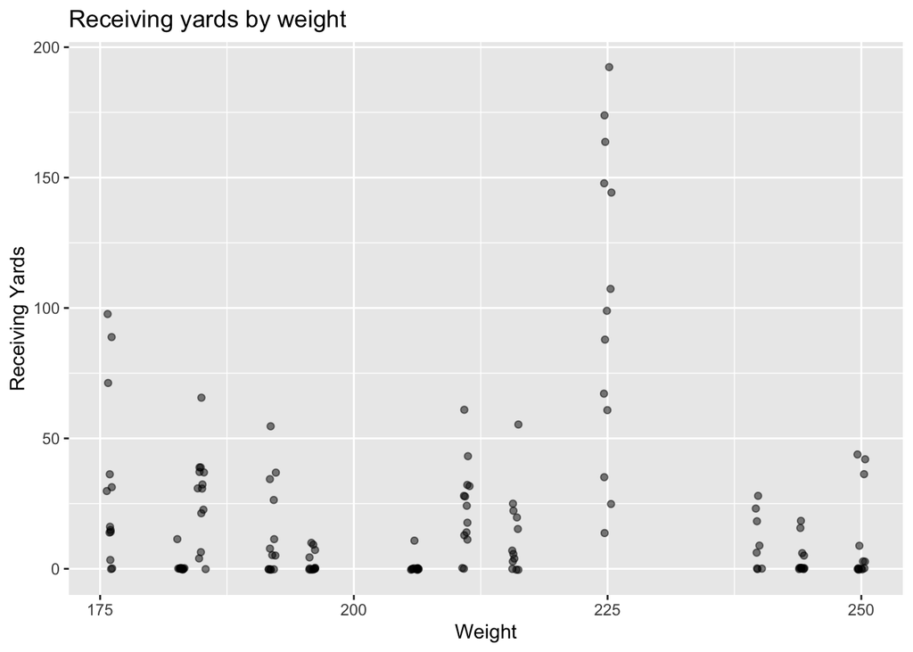

```r
off_bio %>% ggplot(aes(Weight,Receiving_YDS)) + geom_point(position = 'jitter', alpha= .5) +labs(title="Receiving yards by weight",y="Receiving Yards")
```

A question we can ask ourselves is what players are exclusively offensive? The following list shows players that solely play offense.

```r
offClean %>% anti_join(defClean,by="Name") %>% select("Name") %>% distinct()
```

```
## # A tibble: 9 x 1
##   Name
##   <fct>
## 1 Montgomery, David
## 2 Purdy, Brock
## 3 Nwangwu, Kene
## 4 Noland, Zeb
## 5 Kempt, Kyle
## 6 Eaton, Matthew
## 7 Allen, Chase
## 8 Seonbuchner, Sam
## 9 Johnson, Josh
```